# Project2_Part1_Group22

Evaluation:- This time we are taking 100 n_estimators, that means we want to build 100 trees before taking maximum voting or averagess of predictions. More number of trees gives us better performance but makes the code slower.

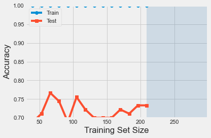

```python
from sklearn.ensemble import RandomForestClassifier
clf_2 = RandomForestClassifier(n_estimators=100, random_state=123)

pred_train, pred_test = [], []
intervals = np.arange(40, X_train.shape[0] + 1,13)

for i in intervals:
    clf_2.fit(X_train[:i], y_train[:i])
    p_train = clf_2.score(X_train[:i], y_train[:i])
    p_test = clf_2.score(X_test, y_test)
    pred_train.append(p_train)
    pred_test.append(p_test)
with plt.style.context(('fivethirtyeight')):
    plt.plot(intervals, pred_train, marker='o', label='Train')
    plt.plot(intervals, pred_test, marker='s', label='Test')
    plt.legend(loc='best', numpoints=1)
    plt.xlim([30, X_train.shape[0] + X_test.shape[0]])
    plt.axvspan(X_train.shape[0],
                X_train.shape[0] + X_test.shape[0],
                alpha=0.2,
                color='steelblue')
    plt.ylim([0.7, 1.0])
    plt.xlabel('Training Set Size')
    plt.ylabel('Accuracy')
    plt.tight_layout()
```

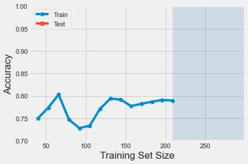

```python
clf_2 = KNeighborsClassifier(n_neighbors=3)
pred_train, pred_test = [], []
intervals = np.arange(40, X_train.shape[0] + 1,13)
for i in intervals:
    clf_2.fit(X_train[:i], y_train[:i])
    p_train = clf_2.score(X_train[:i], y_train[:i])
    p_test = clf_2.score(X_test, y_test)
    pred_train.append(p_train)
    pred_test.append(p_test)

with plt.style.context(('fivethirtyeight')):
    plt.plot(intervals, pred_train, marker='o', label='Train')
    plt.plot(intervals, pred_test, marker='s', label='Test')
    plt.legend(loc='best', numpoints=1)
    plt.xlim([30, X_train.shape[0] + X_test.shape[0]])
    plt.axvspan(X_train.shape[0],
                X_train.shape[0] + X_test.shape[0],
                alpha=0.2,
                color='steelblue')
plt.ylim([0.7, 1.0])
plt.xlabel('Training Set Size')
plt.ylabel('Accuracy')
plt.tight_layout()
```

```python
from sklearn.neighbors import KNeighborsClassifier

rng = np.random.RandomState(seed=12345)

clf = KNeighborsClassifier(n_neighbors=3, weights = 'uniform', algorithm='kd_tree', leaf_size=30, p=2, metric='minkowski', metric_params=None, n_jobs=1)
#print(np.array(y))
idx = np.arange(y.shape[0])

accuracies = []

for i in range(200):
    train_idx = np.array(rng.choice(idx, size=idx.shape[0], replace=True))
    test_idx = np.setdiff1d(idx, train_idx, assume_unique=False)


    #print(X.iloc[train_idx])

    boot_train_X, boot_train_y = X.iloc[train_idx], y.iloc[train_idx]
    boot_test_X, boot_test_y = X.iloc[test_idx], y.iloc[test_idx]

    clf.fit(boot_train_X, boot_train_y)
    acc = clf.score(boot_test_X, boot_test_y)
    accuracies.append(acc)
```

Bootstrapping with the KNeighborsClassifier. Bootstrapping is when we replicate the sample, thousand, sometime zillion times of the sample set. first we begin with small size sample data and then randomly iterate over our bootstrap data to find out proportions.

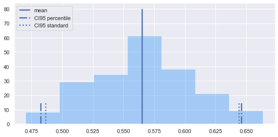

```python
mean = np.mean(accuracies)

se = np.sqrt((1. / (200-1)) * np.sum([(acc - mean) ** 2 for acc in accuracies]))
ci = 1.97 * se

lower = np.percentile(accuracies, 2.5)
upper = np.percentile(accuracies, 97.5)

fig, ax = plt.subplots(figsize=(8,4))
ax.vlines(mean, [0], 80, lw=2.5, linestyle='-', label = 'mean')
ax.vlines(lower, [0], 15, lw=2.5, linestyle='-.', label = 'CI95 percentile')
ax.vlines(upper, [0], 15, lw=2.5, linestyle='-.')

ax.vlines(mean + ci, [0], 15, lw=2.5, linestyle=':', label = 'CI95 standard')
ax.vlines(mean - ci, [0], 15, lw=2.5, linestyle=':')

ax.hist(accuracies, bins=7, color='#0080ff', edgecolor='none', alpha=0.3)
plt.legend(loc='upper left')

#plt.xlim([0.86, 1.01])
plt.tight_layout()

plt.show()
```

```python
from sklearn.linear_model import LogisticRegression

rng = np.random.RandomState(seed=12345)

clf = LogisticRegression(penalty='l2', dual=False, tol=0.0001, C=0.000001, fit_intercept=True, intercept_scaling=1, class_weight=None, random_state=12, solver='lbfgs', max_iter=1000, multi_class='multinomial', verbose=0, warm_start=False, n_jobs=1)

idx = np.arange(y.shape[0])

accuracies = []

for i in range(200):
    train_idx = np.array(rng.choice(idx, size=idx.shape[0], replace=True))
    test_idx = np.setdiff1d(idx, train_idx, assume_unique=False)


    boot_train_X, boot_train_y = X.iloc[train_idx], y.iloc[train_idx]
    boot_test_X, boot_test_y = X.iloc[test_idx], y.iloc[test_idx]

    clf.fit(boot_train_X, boot_train_y)
    acc = clf.score(boot_test_X, boot_test_y)
    accuracies.append(acc)
```

Looks like our Logistic Regression gives higher accuracy of our prediction model, this time giving close to 70 %.

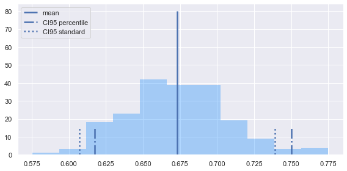

```python
mean = np.mean(accuracies)
se = np.sqrt((1. / (200-1)) * np.sum([(acc - mean) ** 2 for acc in accuracies]))
ci = 1.97 * se

lower = np.percentile(accuracies, 2.5)
upper = np.percentile(accuracies, 97.5)

fig, ax = plt.subplots(figsize=(8,4))
ax.vlines(mean, [0], 80, lw=2.5, linestyle='-', label = 'mean')
ax.vlines(lower, [0], 15, lw=2.5, linestyle='-.', label = 'CI95 percentile')
ax.vlines(upper, [0], 15, lw=2.5, linestyle='-.')

ax.vlines(mean + ci, [0], 15, lw=2.5, linestyle=':', label = 'CI95 standard')
ax.vlines(mean - ci, [0], 15, lw=2.5, linestyle=':')

ax.hist(accuracies, bins=11, color='#0080ff', edgecolor='none', alpha=0.3)
plt.legend(loc='upper left')

#plt.xlim([0.885, 0.922])
plt.tight_layout()

plt.show()
```

In earlier versions, we used the training data and test data. In out of bag Bootstrap, we select the data (x, y) that are not included after the original dataset is run in classifiers that has number of trees. Out-of-bag error can show accurate result as using the test set of same size as the training set.

We implement the out of bag Bootstrap to see the accuracy outcomes too.